# Simple crop model with spatial diversity - analysis of yield experiments

Andreas Angourakis

24 March, 2021

## Load data

Load all experiment output files in the “yield” folder, generated with this version (“Simple crop model with spatial diversity”).

```r
file_names <- paste0("yield/", list.files("yield"))

isThisVersion <- grepl("SIMPLE-crop-model_withSpatialDiversity_yield", file_names)

yieldData <- do.call(rbind, lapply(file_names[isThisVersion], read.csv))
```

Preview the data structure

```r
knitr::kable(head(yieldData))
```

| randomSeed | temperature_annualMaxAt2m | temperature_annualMinAt2m | temperature_meanDailyFluctuation | temperature_dailyLowerDeviation | temperature_dailyUpperDeviation | solar_annualMax | solar_annualMin | solar_meanDailyFluctuation | CO2_annualMin | CO2_annualMax | CO2_meanDailyFluctuation | precipitation_yearlyMean | precipitation_yearlySd | precipitation_dailyCum_nSamples | precipitation_dailyCum_maxSampleSize | precipitation_dailyCum_plateauValue_yearlyMean | precipitation_dailyCum_plateauValue_yearlySd | precipitation_dailyCum_inflection1_yearlyMean | precipitation_dailyCum_inflection1_yearlySd | precipitation_dailyCum_rate1_yearlyMean | precipitation_dailyCum_rate1_yearlySd | precipitation_dailyCum_inflection2_yearlyMean | precipitation_dailyCum_inflection2_yearlySd | precipitation_dailyCum_rate2_yearlyMean | precipitation_dailyCum_rate2_yearlySd | currentYear | currentDayOfYear | precipitation_yearTotal | meanARID | … |
| --- | --- | --- | --- | --- | --- | --- | --- | --- | --- | --- | --- | --- | --- | --- | --- | --- | --- | --- | --- | --- | --- | --- | --- | --- | --- | --- | --- | --- | --- | --- |
| 0 | 37 | 12.8 | 2.2 | 6.8 | 7.9 | 24.2 | 9.2 | 3.3 | 245 | 255 | 1 | 639.0508 | 142.2 | 200 | 10 | 0.6291136 | 0.1 | 40 | 5 | 0.07 | 0.02 | 240 | 20 | 0.08 | 0.02 | 0 | 365 | 650.9614 | 0.7177885 | … |
| 0 | 37 | 12.8 | 2.2 | 6.8 | 7.9 | 24.2 | 9.2 | 3.3 | 245 | 255 | 1 | 639.0508 | 142.2 | 200 | 10 | 0.6291136 | 0.1 | 40 | 5 | 0.07 | 0.02 | 240 | 20 | 0.08 | 0.02 | 0 | 365 | 650.9614 | 0.4924062 | … |
| 0 | 37 | 12.8 | 2.2 | 6.8 | 7.9 | 24.2 | 9.2 | 3.3 | 245 | 255 | 1 | 639.0508 | 142.2 | 200 | 10 | 0.6291136 | 0.1 | 40 | 5 | 0.07 | 0.02 | 240 | 20 | 0.08 | 0.02 | 0 | 365 | 650.9614 | 0.6217397 | … |
| 0 | 37 | 12.8 | 2.2 | 6.8 | 7.9 | 24.2 | 9.2 | 3.3 | 245 | 255 | 1 | 639.0508 | 142.2 | 200 | 10 | 0.6291136 | 0.1 | 40 | 5 | 0.07 | 0.02 | 240 | 20 | 0.08 | 0.02 | 0 | 365 | 650.9614 | 0.7405726 | … |
| 0 | 37 | 12.8 | 2.2 | 6.8 | 7.9 | 24.2 | 9.2 | 3.3 | 245 | 255 | 1 | 639.0508 | 142.2 | 200 | 10 | 0.6291136 | 0.1 | 40 | 5 | 0.07 | 0.02 | 240 | 20 | 0.08 | 0.02 | 0 | 365 | 650.9614 | 0.5051434 | … |
| 0 | 37 | 12.8 | 2.2 | 6.8 | 7.9 | 24.2 | 9.2 | 3.3 | 245 | 255 | 1 | 639.0508 | 142.2 | 200 | 10 | 0.6291136 | 0.1 | 40 | 5 | 0.07 | 0.02 | 240 | 20 | 0.08 | 0.02 | 0 | 365 | 650.9614 | 0.5974389 | … |

## All crops

Visualise simulation results for all crops included in Zhao et al. 2019 (except those taking more than a year to reach maturity; i.e. banana, cotton, peanut and cassava). NOTE: banana is already not used for simulations.

## Preparations

Reconstruct cropTable content:

```r
cropTableNames <- c("crop", "T_sum", "HI", "I_50A", "I_50B", "T_base", "T_opt", "RUE", "I_50maxH", "I_50maxW", "T_heat", "T_extreme", "S_CO2", "S_water", "sowingDay", "harvestDay")

cropTable <- data.frame(matrix(ncol=length(cropTableNames),nrow=0, dimnames=list(NULL, cropTableNames)))

for (aCrop in levels(yieldData$crop))
{
  cropTable <- rbind(cropTable, yieldData[match(aCrop, yieldData$crop), cropTableNames])
}
```

Filter out cassava, cotton and peanut:

```r
notAnnualCrops <- c(" 'cassava'", " 'cotton'", " 'peanut'")
notAnnual <- yieldData$crop == " 'cassava'" | yieldData$crop == " 'cotton'" | yieldData$crop == " 'peanut'"

yieldData <- yieldData[!notAnnual,]

# crop factor variable needs resetting levels
yieldData$crop <- factor(yieldData$crop)
```

Get vector of colours to represent crops:

```r
cropColours <- rainbow(nlevels(yieldData$crop), s = 0.8, end = 0.9)
```

Precalculate ranges of ARID and yield:

```r
minARID = round(min(c(yieldData$meanARID, yieldData$meanARID_grow), na.rm = TRUE), digits = 2)
maxARID = round(max(c(yieldData$meanARID, yieldData$meanARID_grow), na.rm = TRUE), digits = 2)

minYield = round(min(yieldData$yield), digits = -1)
maxYield = round(max(yieldData$yield), digits = -1)

minElevation = round(min(yieldData$elevation, na.rm = TRUE), digits = -1)
maxElevation = round(max(yieldData$elevation, na.rm = TRUE), digits = -1)

minDC = round(min(yieldData$DC, na.rm = TRUE), digits = 2)
maxDC = round(max(yieldData$DC, na.rm = TRUE), digits = 2)

minWHC = round(min(yieldData$WHC, na.rm = TRUE), digits = 2)
maxWHC = round(max(yieldData$WHC, na.rm = TRUE), digits = 2)

minAlbedo = round(min(yieldData$albedo, na.rm = TRUE), digits = 2)
maxAlbedo = round(max(yieldData$albedo, na.rm = TRUE), digits = 2)
```

## Summary statistics per crop

```r
yieldData_summary <- tapply(as.numeric(as.character(yieldData$yield)), yieldData$crop, summary)

yieldData_summary <- data.frame(Reduce(rbind, yieldData_summary), row.names = names(yieldData_summary))
```

```r
knitr::kable(yieldData_summary)
```

|  | Min. | X1st.Qu. | Median | Mean | X3rd.Qu. | Max. |
| --- | --- | --- | --- | --- | --- | --- |
| ‘carrot’ | 0.00000 | 0.0000000 | 0.00000 | 0.00000 | 0.0000 | 0.0000 |
| ‘dry bean’ | 39.77323 | 99.7875152 | 138.04051 | 142.10117 | 179.2089 | 319.9080 |
| ‘greenbean’ | 265.14017 | 321.6465355 | 343.35884 | 343.65089 | 362.6656 | 451.7595 |
| ‘maize’ | 0.00000 | 107.2547509 | 246.12363 | 287.56321 | 427.5556 | 1408.1039 |
| ‘potato 1’ | 1166.78468 | 1310.1273733 | 1386.73555 | 1387.55447 | 1447.1874 | 1784.9024 |
| ‘potato 2’ | 1027.97392 | 1165.6330248 | 1236.60241 | 1237.03806 | 1292.9409 | 1590.2670 |
| ‘potato 3’ | 580.03798 | 655.1878508 | 695.09275 | 695.43542 | 726.8206 | 898.7303 |
| ‘potato 4’ | 575.42161 | 655.4905521 | 695.38885 | 695.55159 | 726.6423 | 899.8745 |
| ‘potato 5’ | 1228.84560 | 1387.5865958 | 1469.55606 | 1469.77962 | 1532.8896 | 1891.2553 |
| ‘potato 6’ | 1247.26154 | 1394.7612322 | 1477.37943 | 1477.57982 | 1539.7144 | 1897.5005 |
| ‘rice’ | 0.00000 | 145.2532419 | 209.46807 | 222.27540 | 291.1395 | 564.4086 |
| ‘soybean 1’ | 73.11294 | 149.8101776 | 193.91008 | 196.23320 | 238.4853 | 387.3273 |
| ‘soybean 2’ | 85.50341 | 174.2560419 | 223.87381 | 226.78671 | 274.1501 | 451.4391 |
| ‘sweetcorn’ | 0.00000 | 7.0465511 | 55.56285 | 101.11178 | 157.1649 | 793.8814 |
| ‘tomato 1’ | 0.00000 | 1.2891238 | 39.27599 | 96.40991 | 148.8108 | 900.7742 |
| ‘tomato 2’ | 0.00000 | 0.9301013 | 30.41383 | 70.97555 | 110.9608 | 566.9059 |
| ‘wheat 1’ | 0.00000 | 316.5471492 | 387.40010 | 326.30991 | 449.1688 | 512.2972 |
| ‘wheat 2’ | 0.00000 | 330.6847933 | 401.76636 | 335.06729 | 457.5385 | 535.4905 |

```r
plotName = "plots/SIMPLE-crop-model_withSpatialDiversity/yieldPerCrop.png"

grScale = 2
fontRescale = 0
fontRescaleDay = 0

png(plotName, width = grScale * 500, height = grScale * 300)

par(mar = c(6,5,1,1))

boxplot(yield ~ factor(crop), data = yieldData,#[yieldData$yield > 0,], # show only non-zero yield
        ylab = expression(paste("yield (", g/m^2, ")")), xlab = "",
        las = 2,
        col = cropColours)

dev.off()
```

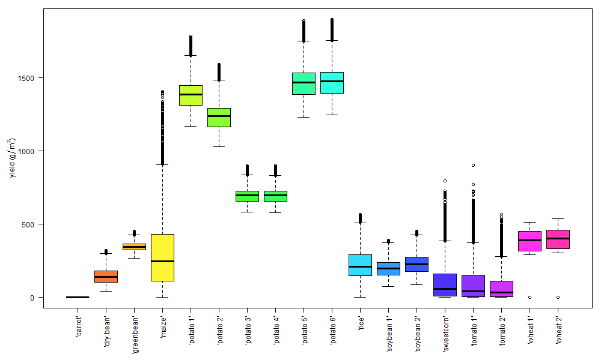

```r
knitr::include_graphics(plotName)
```

## Effect of elevation on ARID

Plotting ARID vs elevation:

```r
plotName = "plots/SIMPLE-crop-model_withSpatialDiversity/ARIDvsElevation.png"

grScale = 2
fontRescale = 0.5

png(plotName, width = grScale * 500, height = grScale * 300)

layout(matrix(c(1, 2, 3, 4, 4, 4), nrow = 3, ncol = 2),
       heights = c(10, 10, 2), widths = c(10, 3))

par(mar = c(1,5,1,1), cex.lab = 0.8 * grScale)

plot(c(minElevation, maxElevation),
     c(minARID, maxARID),
     xaxt ='n',
     xlab = "",
     ylab = "mean ARID (current year)")

for (aCrop in levels(yieldData$crop))
{
  points(yieldData$elevation[yieldData$crop == aCrop],
         yieldData$meanARID[yieldData$crop == aCrop],
         col = cropColours[match(aCrop, levels(yieldData$crop))],
         pch = 20
  )
  abline(lm(meanARID ~ elevation, data = yieldData[yieldData$crop == aCrop,]),
         col = cropColours[match(aCrop, levels(yieldData$crop))],
         lwd = 2)
}

plot(c(minElevation, maxElevation),
     c(minARID, maxARID),
     xaxt ='n',
     xlab = "",
     ylab = "mean ARID (grow seasons)")

for (aCrop in levels(yieldData$crop))
{
  points(yieldData$elevation[yieldData$crop == aCrop],
         yieldData$meanARID_grow[yieldData$crop == aCrop],
         col = cropColours[match(aCrop, levels(yieldData$crop))],
         pch = 20
  )
  abline(lm(meanARID_grow ~ elevation, data = yieldData[yieldData$crop == aCrop,]),
         col = cropColours[match(aCrop, levels(yieldData$crop))],
         lwd = 2)
}

par(mar = c(1, 1, 1, 0.1))

plot(c(minElevation, maxElevation), c(0, 1), ann = F, bty = 'n', type = 'n', xaxt = 'n', yaxt = 'n')

axis(3,
     at = seq(minElevation, maxElevation, by = 5),
     tck = 0, lwd = 0)

mtext("elevation (m)", side = 1, line = -2)

par(mar = c(0, 0, 0, 0), cex = 0.8 * grScale)

plot(c(0, 1), c(0, 1), ann = F, bty = 'n', type = 'n', xaxt = 'n', yaxt = 'n')

legend(x = 0, y = 1,
       legend = stringi::stri_c(cropTable$S_water[!cropTable$crop %in% notAnnualCrops], " (", levels(yieldData$crop), ")"),
       title = "S_water (Crop-cultivar)",
       fill = cropColours)

dev.off()
```

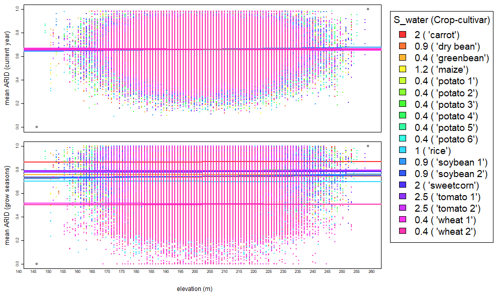

```r
knitr::include_graphics(plotName)
```

Calculate correlation and linear models fitness:

```r
linearModels.table <- data.frame(
  levels(yieldData$crop),
  numeric(nlevels(yieldData$crop)),
  numeric(nlevels(yieldData$crop)),
  numeric(nlevels(yieldData$crop)),
  numeric(nlevels(yieldData$crop)),
  numeric(nlevels(yieldData$crop)),
  numeric(nlevels(yieldData$crop))
)

names(linearModels.table) <- c("crop", "correlation_Pearson", "intercept", "intercept_p", "speed", "speed_p", "adjrsquared")

for (aCrop in levels(yieldData$crop))
{
  linearModels.table$correlation_Pearson[linearModels.table$crop == aCrop] <-
    cor(x = yieldData$elevation[yieldData$crop == aCrop], y = yieldData$meanARID_grow[yieldData$crop == aCrop], use = "pairwise.complete.obs")

  linearModel <- lm(meanARID_grow ~ elevation, data = yieldData[yieldData$crop == aCrop,])

  linearModels.table$intercept[linearModels.table$crop == aCrop] <- summary(linearModel)$coefficients[1,1]
  linearModels.table$intercept_p[linearModels.table$crop == aCrop] <- summary(linearModel)$coefficients[1,4]
  linearModels.table$speed[linearModels.table$crop == aCrop] <- summary(linearModel)$coefficients[2,1]
  linearModels.table$speed_p[linearModels.table$crop == aCrop] <- summary(linearModel)$coefficients[2,4]
  linearModels.table$adjrsquared[linearModels.table$crop == aCrop] <- summary(linearModel)$adj.r.squared
}
```

```r
knitr::kable(linearModels.table)
```

| crop | correlation_Pearson | intercept | intercept_p | speed | speed_p | adjrsquared |
| --- | --- | --- | --- | --- | --- | --- |
| ‘carrot’ | 0.0049835 | 0.8607058 | 0 | 0.0000421 | 0.3887741 | -0.0000086 |
| ‘dry bean’ | 0.0097498 | 0.7170729 | 0 | 0.0001147 | 0.0955980 | 0.0000608 |
| ‘greenbean’ | 0.0022418 | 0.7562050 | 0 | 0.0000253 | 0.6974299 | -0.0000282 |
| ‘maize’ | 0.0081007 | 0.7714857 | 0 | 0.0000707 | 0.1681543 | 0.0000311 |
| ‘potato 1’ | -0.0069193 | 0.8064059 | 0 | -0.0000620 | 0.2310611 | 0.0000145 |
| ‘potato 2’ | -0.0021134 | 0.7956317 | 0 | -0.0000186 | 0.7167364 | -0.0000295 |
| ‘potato 3’ | -0.0047963 | 0.8016456 | 0 | -0.0000427 | 0.4078650 | -0.0000106 |
| ‘potato 4’ | 0.0119952 | 0.7714019 | 0 | 0.0001065 | 0.0376010 | 0.0001106 |
| ‘potato 5’ | 0.0019947 | 0.7892364 | 0 | 0.0000176 | 0.7310610 | -0.0000297 |
| ‘potato 6’ | -0.0048793 | 0.8005776 | 0 | -0.0000436 | 0.3992844 | -0.0000097 |
| ‘rice’ | -0.0049897 | 0.7164653 | 0 | -0.0000663 | 0.3857734 | -0.0000082 |
| ‘soybean 1’ | 0.0296227 | 0.6805204 | 0 | 0.0003173 | 0.0000003 | 0.0008445 |
| ‘soybean 2’ | 0.0120087 | 0.7198775 | 0 | 0.0001266 | 0.0368998 | 0.0001111 |
| ‘sweetcorn’ | 0.0065119 | 0.7705374 | 0 | 0.0000587 | 0.2622967 | 0.0000087 |
| ‘tomato 1’ | 0.0030934 | 0.7869185 | 0 | 0.0000278 | 0.5955884 | -0.0000244 |
| ‘tomato 2’ | 0.0139102 | 0.7670206 | 0 | 0.0001251 | 0.0173492 | 0.0001593 |
| ‘wheat 1’ | -0.0080609 | 0.5373838 | 0 | -0.0001210 | 0.2146372 | 0.0000228 |
| ‘wheat 2’ | 0.0037392 | 0.4969948 | 0 | 0.0000563 | 0.5654026 | -0.0000283 |

## Effect of drainage coefficient (DC) on ARID

Plotting ARID vs DC:

```r
plotName = "plots/SIMPLE-crop-model_withSpatialDiversity/ARIDvsDC.png"

grScale = 2
fontRescale = 0.5

png(plotName, width = grScale * 500, height = grScale * 300)

layout(matrix(c(1, 2, 3, 4, 4, 4), nrow = 3, ncol = 2),
       heights = c(10, 10, 2), widths = c(10, 3))

par(mar = c(1,5,1,1), cex.lab = 0.8 * grScale)

plot(c(minDC, maxDC),
     c(minARID, maxARID),
     xaxt ='n',
     xlab = "",
     ylab = "mean ARID (current year)")

for (aCrop in levels(yieldData$crop))
{
  points(yieldData$DC[yieldData$crop == aCrop],
         yieldData$meanARID[yieldData$crop == aCrop],
         col = cropColours[match(aCrop, levels(yieldData$crop))],
         pch = 20
  )
  abline(lm(meanARID ~ DC, data = yieldData[yieldData$crop == aCrop,]),
         col = cropColours[match(aCrop, levels(yieldData$crop))],
         lwd = 2)
}

plot(c(minDC, maxDC),
     c(minARID, maxARID),
     xaxt ='n',
     xlab = "",
     ylab = "mean ARID (grow seasons)")

for (aCrop in levels(yieldData$crop))
{
  points(yieldData$DC[yieldData$crop == aCrop],
         yieldData$meanARID_grow[yieldData$crop == aCrop],
         col = cropColours[match(aCrop, levels(yieldData$crop))],
         pch = 20
  )
  abline(lm(meanARID_grow ~ DC, data = yieldData[yieldData$crop == aCrop,]),
         col = cropColours[match(aCrop, levels(yieldData$crop))],
         lwd = 2)
}

par(mar = c(1, 1, 1, 0.1))

plot(c(minDC, maxDC), c(0, 1), ann = F, bty = 'n', type = 'n', xaxt = 'n', yaxt = 'n')

axis(3,
     at = seq(minDC, maxDC, by = 0.05),
     tck = 0, lwd = 0)

mtext(expression("drainage coefficient " (m^3*m^-3) ), side = 1, line = -2)

par(mar = c(0, 0, 0, 0), cex = 0.8 * grScale)

plot(c(0, 1), c(0, 1), ann = F, bty = 'n', type = 'n', xaxt = 'n', yaxt = 'n')

legend(x = 0, y = 1,
       legend = stringi::stri_c(cropTable$S_water[!cropTable$crop %in% notAnnualCrops], " (", levels(yieldData$crop), ")"),
       title = "S_water (Crop-cultivar)",
       fill = cropColours)

dev.off()
```

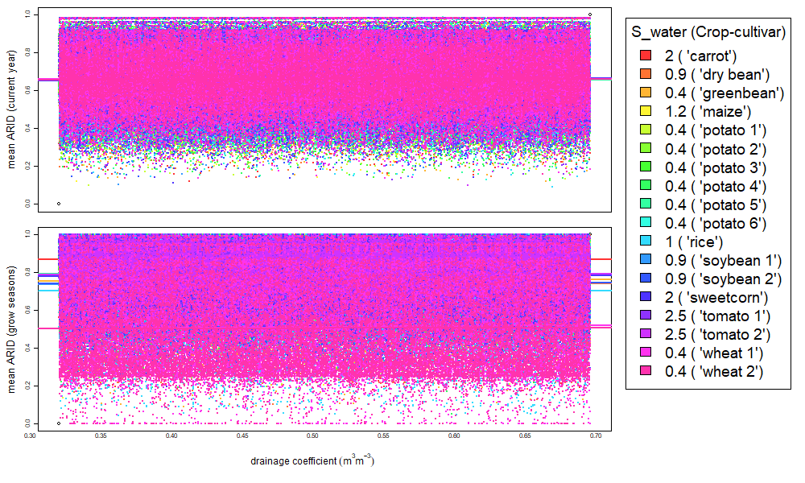

```r
knitr::include_graphics(plotName)
```

Calculate correlation and linear models fitness:

```r
linearModels.table <- data.frame(
  levels(yieldData$crop),
  numeric(nlevels(yieldData$crop)),
  numeric(nlevels(yieldData$crop)),
  numeric(nlevels(yieldData$crop)),
  numeric(nlevels(yieldData$crop)),
  numeric(nlevels(yieldData$crop)),
  numeric(nlevels(yieldData$crop))
)

names(linearModels.table) <- c("crop", "correlation_Pearson", "intercept", "intercept_p", "speed", "speed_p", "adjrsquared")

for (aCrop in levels(yieldData$crop))
{
  linearModels.table$correlation_Pearson[linearModels.table$crop == aCrop] <-
    cor(x = yieldData$DC[yieldData$crop == aCrop], y = yieldData$meanARID_grow[yieldData$crop == aCrop], use = "pairwise.complete.obs")

  linearModel <- lm(meanARID_grow ~ DC, data = yieldData[yieldData$crop == aCrop,])

  linearModels.table$intercept[linearModels.table$crop == aCrop] <- summary(linearModel)$coefficients[1,1]
  linearModels.table$intercept_p[linearModels.table$crop == aCrop] <- summary(linearModel)$coefficients[1,4]
  linearModels.table$speed[linearModels.table$crop == aCrop] <- summary(linearModel)$coefficients[2,1]
  linearModels.table$speed_p[linearModels.table$crop == aCrop] <- summary(linearModel)$coefficients[2,4]
  linearModels.table$adjrsquared[linearModels.table$crop == aCrop] <- summary(linearModel)$adj.r.squared
}
```

```r
knitr::kable(linearModels.table)
```

| crop | correlation_Pearson | intercept | intercept_p | speed | speed_p | adjrsquared |
| --- | --- | --- | --- | --- | --- | --- |
| ‘carrot’ | 0.0085272 | 0.8648620 | 0 | 0.0085558 | 0.1402929 | 0.0000393 |
| ‘dry bean’ | 0.0129196 | 0.7307964 | 0 | 0.0183970 | 0.0272128 | 0.0001327 |
| ‘greenbean’ | 0.0213209 | 0.7466868 | 0 | 0.0291114 | 0.0002172 | 0.0004214 |
| ‘maize’ | 0.0206320 | 0.7746034 | 0 | 0.0219447 | 0.0004474 | 0.0003911 |
| ‘potato 1’ | 0.0081320 | 0.7895963 | 0 | 0.0088398 | 0.1592707 | 0.0000328 |
| ‘potato 2’ | 0.0115471 | 0.7857213 | 0 | 0.0124926 | 0.0474314 | 0.0000994 |
| ‘potato 3’ | 0.0072290 | 0.7892192 | 0 | 0.0077899 | 0.2122261 | 0.0000187 |
| ‘potato 4’ | 0.0198017 | 0.7819322 | 0 | 0.0215365 | 0.0005980 | 0.0003588 |
| ‘potato 5’ | 0.0124353 | 0.7860760 | 0 | 0.0134442 | 0.0321230 | 0.0001210 |
| ‘potato 6’ | 0.0105233 | 0.7861454 | 0 | 0.0114433 | 0.0690728 | 0.0000772 |
| ‘rice’ | 0.0042297 | 0.6997952 | 0 | 0.0068344 | 0.4622206 | -0.0000152 |
| ‘soybean 1’ | 0.0251375 | 0.7277545 | 0 | 0.0326787 | 0.0000121 | 0.0005989 |
| ‘soybean 2’ | 0.0117399 | 0.7376653 | 0 | 0.0150874 | 0.0413335 | 0.0001047 |
| ‘sweetcorn’ | 0.0215731 | 0.7704988 | 0 | 0.0236090 | 0.0002040 | 0.0004317 |
| ‘tomato 1’ | 0.0126074 | 0.7855732 | 0 | 0.0138008 | 0.0305265 | 0.0001250 |
| ‘tomato 2’ | 0.0138291 | 0.7844687 | 0 | 0.0151349 | 0.0180128 | 0.0001571 |
| ‘wheat 1’ | 0.0227284 | 0.4918145 | 0 | 0.0426985 | 0.0004665 | 0.0004744 |
| ‘wheat 2’ | 0.0111673 | 0.4980329 | 0 | 0.0203837 | 0.0860111 | 0.0000824 |

## Effect of water holding capacity (WHC) on ARID

```r
plotName = "plots/SIMPLE-crop-model_withSpatialDiversity/ARIDvsWHC.png"

grScale = 2
fontRescale = 0.5

png(plotName, width = grScale * 500, height = grScale * 300)

layout(matrix(c(1, 2, 3, 4, 4, 4), nrow = 3, ncol = 2),
       heights = c(10, 10, 2), widths = c(10, 3))

par(mar = c(1,5,1,1), cex.lab = 0.8 * grScale)

plot(c(minWHC, maxWHC),
     c(minARID, maxARID),
     xaxt ='n',
     xlab = "",
     ylab = "mean ARID (current year)")

for (aCrop in levels(yieldData$crop))
{
  points(yieldData$WHC[yieldData$crop == aCrop],
         yieldData$meanARID[yieldData$crop == aCrop],
         col = cropColours[match(aCrop, levels(yieldData$crop))],
         pch = 20
  )
  abline(lm(meanARID ~ WHC, data = yieldData[yieldData$crop == aCrop,]),
         col = cropColours[match(aCrop, levels(yieldData$crop))],
         lwd = 2)
}

plot(c(minWHC, maxWHC),
     c(minARID, maxARID),
     xaxt ='n',
     xlab = "",
     ylab = "mean ARID (grow seasons)")

for (aCrop in levels(yieldData$crop))
{
  points(yieldData$WHC[yieldData$crop == aCrop],
         yieldData$meanARID_grow[yieldData$crop == aCrop],
         col = cropColours[match(aCrop, levels(yieldData$crop))],
         pch = 20
  )
  abline(lm(meanARID_grow ~ WHC, data = yieldData[yieldData$crop == aCrop,]),
         col = cropColours[match(aCrop, levels(yieldData$crop))],
         lwd = 2)
}

par(mar = c(1, 1, 1, 0.1))

plot(c(minWHC, maxWHC), c(0, 1), ann = F, bty = 'n', type = 'n', xaxt = 'n', yaxt = 'n')

axis(3,
     at = seq(minWHC, maxWHC, by = 0.05),
     tck = 0, lwd = 0)

mtext(expression("water holding capacity " (m^3*m^-3) ), side = 1, line = -2)

par(mar = c(0, 0, 0, 0), cex = 0.8 * grScale)

plot(c(0, 1), c(0, 1), ann = F, bty = 'n', type = 'n', xaxt = 'n', yaxt = 'n')

legend(x = 0, y = 1,
       legend = stringi::stri_c(cropTable$S_water[!cropTable$crop %in% notAnnualCrops], " (", levels(yieldData$crop), ")"),
       title = "S_water (Crop-cultivar)",
       fill = cropColours)

dev.off()
```

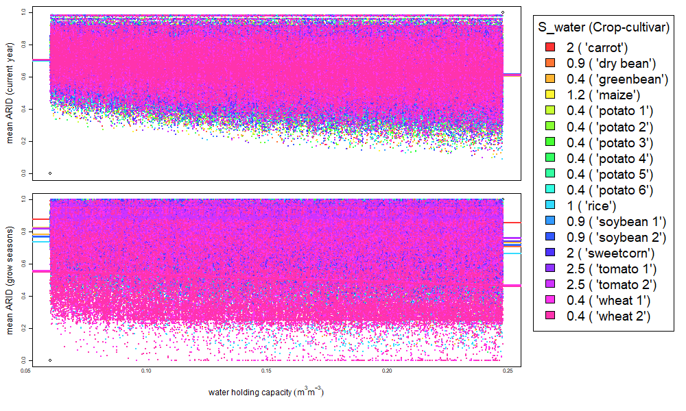

```r
knitr::include_graphics(plotName)
```

Calculate correlation and linear models fitness:

```r
linearModels.table <- data.frame(
  levels(yieldData$crop),
  numeric(nlevels(yieldData$crop)),
  numeric(nlevels(yieldData$crop)),
  numeric(nlevels(yieldData$crop)),
  numeric(nlevels(yieldData$crop)),
  numeric(nlevels(yieldData$crop)),
  numeric(nlevels(yieldData$crop))
)

names(linearModels.table) <- c("crop", "correlation_Pearson", "intercept", "intercept_p", "speed", "speed_p", "adjrsquared")

for (aCrop in levels(yieldData$crop))
{
  linearModels.table$correlation_Pearson[linearModels.table$crop == aCrop] <-
    cor(x = yieldData$WHC[yieldData$crop == aCrop], y = yieldData$meanARID_grow[yieldData$crop == aCrop], use = "pairwise.complete.obs")

  linearModel <- lm(meanARID_grow ~ WHC, data = yieldData[yieldData$crop == aCrop,])

  linearModels.table$intercept[linearModels.table$crop == aCrop] <- summary(linearModel)$coefficients[1,1]
  linearModels.table$intercept_p[linearModels.table$crop == aCrop] <- summary(linearModel)$coefficients[1,4]
  linearModels.table$speed[linearModels.table$crop == aCrop] <- summary(linearModel)$coefficients[2,1]
  linearModels.table$speed_p[linearModels.table$crop == aCrop] <- summary(linearModel)$coefficients[2,4]
  linearModels.table$adjrsquared[linearModels.table$crop == aCrop] <- summary(linearModel)$adj.r.squared
}
```

```r
knitr::kable(linearModels.table)
```

| crop | correlation_Pearson | intercept | intercept_p | speed | speed_p | adjrsquared |
| --- | --- | --- | --- | --- | --- | --- |
| ‘carrot’ | -0.0576890 | 0.8864454 | 0 | -0.1154394 | 0 | 0.0032947 |
| ‘dry bean’ | -0.1037187 | 0.7840343 | 0 | -0.2926888 | 0 | 0.0107237 |
| ‘greenbean’ | -0.0942897 | 0.8001210 | 0 | -0.2578982 | 0 | 0.0088576 |
| ‘maize’ | -0.1828022 | 0.8449242 | 0 | -0.3963862 | 0 | 0.0333832 |
| ‘potato 1’ | -0.1454126 | 0.8410631 | 0 | -0.3153012 | 0 | 0.0211121 |
| ‘potato 2’ | -0.1445993 | 0.8391066 | 0 | -0.3134622 | 0 | 0.0208757 |
| ‘potato 3’ | -0.1378907 | 0.8382170 | 0 | -0.3014857 | 0 | 0.0189809 |
| ‘potato 4’ | -0.1330049 | 0.8361165 | 0 | -0.2885244 | 0 | 0.0176576 |
| ‘potato 5’ | -0.1405683 | 0.8384958 | 0 | -0.3037926 | 0 | 0.0197264 |
| ‘potato 6’ | -0.1324367 | 0.8358376 | 0 | -0.2926591 | 0 | 0.0175065 |
| ‘rice’ | -0.1129910 | 0.7575460 | 0 | -0.3637312 | 0 | 0.0127343 |
| ‘soybean 1’ | -0.0908206 | 0.7799233 | 0 | -0.2385932 | 0 | 0.0082156 |
| ‘soybean 2’ | -0.1024567 | 0.7851518 | 0 | -0.2648926 | 0 | 0.0104646 |
| ‘sweetcorn’ | -0.1823406 | 0.8418128 | 0 | -0.3975383 | 0 | 0.0332155 |
| ‘tomato 1’ | -0.1300717 | 0.8355266 | 0 | -0.2855089 | 0 | 0.0168852 |
| ‘tomato 2’ | -0.1437920 | 0.8394390 | 0 | -0.3148545 | 0 | 0.0206427 |
| ‘wheat 1’ | -0.1163702 | 0.5787369 | 0 | -0.4342302 | 0 | 0.0135004 |
| ‘wheat 2’ | -0.1153035 | 0.5710012 | 0 | -0.4228244 | 0 | 0.0132531 |

## Effect of albedo on ARID

```r
plotName = "plots/SIMPLE-crop-model_withSpatialDiversity/ARIDvsAlbedo.png"

grScale = 2
fontRescale = 0.5

png(plotName, width = grScale * 500, height = grScale * 300)

layout(matrix(c(1, 2, 3, 4, 4, 4), nrow = 3, ncol = 2),
       heights = c(10, 10, 2), widths = c(10, 3))

par(mar = c(1,5,1,1), cex.lab = 0.8 * grScale)

plot(c(minAlbedo, maxAlbedo),
     c(minARID, maxARID),
     xaxt ='n',
     xlab = "",
     ylab = "mean ARID (current year)")

for (aCrop in levels(yieldData$crop))
{
  points(yieldData$albedo[yieldData$crop == aCrop],
         yieldData$meanARID[yieldData$crop == aCrop],
         col = cropColours[match(aCrop, levels(yieldData$crop))],
         pch = 20
  )
  abline(lm(meanARID ~ albedo, data = yieldData[yieldData$crop == aCrop,]),
         col = cropColours[match(aCrop, levels(yieldData$crop))],
         lwd = 2)
}

plot(c(minAlbedo, maxAlbedo),
     c(minARID, maxARID),
     xaxt ='n',
     xlab = "",
     ylab = "mean ARID (grow seasons)")

for (aCrop in levels(yieldData$crop))
{
  points(yieldData$albedo[yieldData$crop == aCrop],
         yieldData$meanARID_grow[yieldData$crop == aCrop],
         col = cropColours[match(aCrop, levels(yieldData$crop))],
         pch = 20
  )
  abline(lm(meanARID_grow ~ albedo, data = yieldData[yieldData$crop == aCrop,]),
         col = cropColours[match(aCrop, levels(yieldData$crop))],
         lwd = 2)
}

par(mar = c(1, 1, 1, 0.1))

plot(c(minAlbedo, maxAlbedo), c(0, 1), ann = F, bty = 'n', type = 'n', xaxt = 'n', yaxt = 'n')

axis(3,
     at = seq(minAlbedo, maxAlbedo, by = 0.05),
     tck = 0, lwd = 0)

mtext("albedo", side = 1, line = -2)

par(mar = c(0, 0, 0, 0), cex = 0.8 * grScale)

plot(c(0, 1), c(0, 1), ann = F, bty = 'n', type = 'n', xaxt = 'n', yaxt = 'n')

legend(x = 0, y = 1,
       legend = stringi::stri_c(cropTable$S_water[!cropTable$crop %in% notAnnualCrops], " (", levels(yieldData$crop), ")"),
       title = "S_water (Crop-cultivar)",
       fill = cropColours)

dev.off()
```

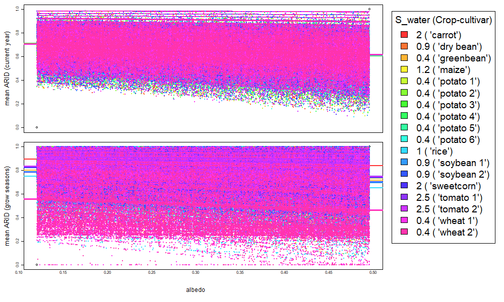

```r
knitr::include_graphics(plotName)
```

Calculate correlation and linear models fitness:

```r
linearModels.table <- data.frame(
  levels(yieldData$crop),
  numeric(nlevels(yieldData$crop)),
  numeric(nlevels(yieldData$crop)),
  numeric(nlevels(yieldData$crop)),
  numeric(nlevels(yieldData$crop)),
  numeric(nlevels(yieldData$crop)),
  numeric(nlevels(yieldData$crop))
)

names(linearModels.table) <- c("crop", "correlation_Pearson", "intercept", "intercept_p", "speed", "speed_p", "adjrsquared")

for (aCrop in levels(yieldData$crop))
{
  linearModels.table$correlation_Pearson[linearModels.table$crop == aCrop] <-
    cor(x = yieldData$albedo[yieldData$crop == aCrop], y = yieldData$meanARID_grow[yieldData$crop == aCrop], use = "pairwise.complete.obs")

  linearModel <- lm(meanARID_grow ~ albedo, data = yieldData[yieldData$crop == aCrop,])

  linearModels.table$intercept[linearModels.table$crop == aCrop] <- summary(linearModel)$coefficients[1,1]
  linearModels.table$intercept_p[linearModels.table$crop == aCrop] <- summary(linearModel)$coefficients[1,4]
  linearModels.table$speed[linearModels.table$crop == aCrop] <- summary(linearModel)$coefficients[2,1]
  linearModels.table$speed_p[linearModels.table$crop == aCrop] <- summary(linearModel)$coefficients[2,4]
  linearModels.table$adjrsquared[linearModels.table$crop == aCrop] <- summary(linearModel)$adj.r.squared
}
```

```r
knitr::kable(linearModels.table)
```

| crop | correlation_Pearson | intercept | intercept_p | speed | speed_p | adjrsquared |
| --- | --- | --- | --- | --- | --- | --- |
| ‘carrot’ | -0.1394156 | 0.9113675 | 0 | -0.1406134 | 0 | 0.0194039 |
| ‘dry bean’ | -0.1533635 | 0.8070650 | 0 | -0.2220470 | 0 | 0.0234870 |
| ‘greenbean’ | -0.1534263 | 0.8243587 | 0 | -0.2098861 | 0 | 0.0235072 |
| ‘maize’ | -0.2173864 | 0.8562218 | 0 | -0.2364523 | 0 | 0.0472239 |
| ‘potato 1’ | -0.1937691 | 0.8568417 | 0 | -0.2102446 | 0 | 0.0375143 |
| ‘potato 2’ | -0.1832874 | 0.8515313 | 0 | -0.1984297 | 0 | 0.0335615 |
| ‘potato 3’ | -0.2011412 | 0.8585232 | 0 | -0.2184499 | 0 | 0.0404256 |
| ‘potato 4’ | -0.1878640 | 0.8533862 | 0 | -0.2018834 | 0 | 0.0352608 |
| ‘potato 5’ | -0.1919027 | 0.8548748 | 0 | -0.2083332 | 0 | 0.0367942 |
| ‘potato 6’ | -0.1944388 | 0.8556290 | 0 | -0.2133293 | 0 | 0.0377742 |
| ‘rice’ | -0.1513211 | 0.7760113 | 0 | -0.2423391 | 0 | 0.0228657 |
| ‘soybean 1’ | -0.1709813 | 0.8104874 | 0 | -0.2234458 | 0 | 0.0292025 |
| ‘soybean 2’ | -0.1542931 | 0.8048571 | 0 | -0.1985701 | 0 | 0.0237740 |
| ‘sweetcorn’ | -0.1937742 | 0.8453601 | 0 | -0.2126112 | 0 | 0.0375160 |
| ‘tomato 1’ | -0.1837140 | 0.8534802 | 0 | -0.2015969 | 0 | 0.0337180 |
| ‘tomato 2’ | -0.1953541 | 0.8563878 | 0 | -0.2135475 | 0 | 0.0381304 |
| ‘wheat 1’ | -0.1220623 | 0.5820608 | 0 | -0.2289755 | 0 | 0.0148576 |
| ‘wheat 2’ | -0.1250768 | 0.5777173 | 0 | -0.2304428 | 0 | 0.0156026 |

## Effect of albedo on yield

```r
plotName = "plots/SIMPLE-crop-model_withSpatialDiversity/yieldvsAlbedo.png"

grScale = 2
fontRescale = 0.5

png(plotName, width = grScale * 500, height = grScale * 300)

layout(matrix(c(1, 2), nrow = 1, ncol = 2), widths = c(10, 3))

par(mar = c(5,5,1,1), cex.lab = 0.8 * grScale)

plot(c(minAlbedo, maxAlbedo),
     c(minYield, maxYield),
     xlab = "albedo",
     ylab = "yield")

for (aCrop in levels(yieldData$crop))
{
  points(yieldData$albedo[yieldData$crop == aCrop],
         yieldData$yield[yieldData$crop == aCrop],
         col = cropColours[match(aCrop, levels(yieldData$crop))],
         pch = 20
  )
  abline(lm(yield ~ albedo, data = yieldData[yieldData$crop == aCrop,]),
         col = cropColours[match(aCrop, levels(yieldData$crop))],
         lwd = 2)
}

par(mar = c(0, 0, 0, 0), cex = 0.8 * grScale)

plot(c(0, 1), c(0, 1), ann = F, bty = 'n', type = 'n', xaxt = 'n', yaxt = 'n')

legend(x = 0, y = 1,
       legend = stringi::stri_c(cropTable$S_water[!cropTable$crop %in% notAnnualCrops], " (", levels(yieldData$crop), ")"),
       title = "S_water (Crop-cultivar)",
       fill = cropColours)

dev.off()
```

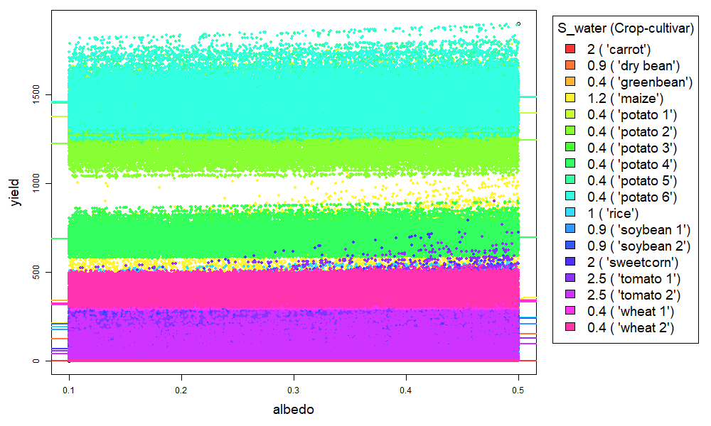

```r
knitr::include_graphics(plotName)
```

Calculate correlation and linear models fitness:

```r
linearModels.table <- data.frame(
  levels(yieldData$crop),
  numeric(nlevels(yieldData$crop)),
  numeric(nlevels(yieldData$crop)),
  numeric(nlevels(yieldData$crop)),
  numeric(nlevels(yieldData$crop)),
  numeric(nlevels(yieldData$crop)),
  numeric(nlevels(yieldData$crop))
)

names(linearModels.table) <- c("crop", "correlation_Pearson", "intercept", "intercept_p", "speed", "speed_p", "adjrsquared")

for (aCrop in levels(yieldData$crop))
{
  linearModels.table$correlation_Pearson[linearModels.table$crop == aCrop] <-
    cor(x = yieldData$albedo[yieldData$crop == aCrop], y = yieldData$yield[yieldData$crop == aCrop], use = "pairwise.complete.obs")

  linearModel <- lm(yield ~ albedo, data = yieldData[yieldData$crop == aCrop,])

  linearModels.table$intercept[linearModels.table$crop == aCrop] <- summary(linearModel)$coefficients[1,1]
  linearModels.table$intercept_p[linearModels.table$crop == aCrop] <- summary(linearModel)$coefficients[1,4]
  linearModels.table$speed[linearModels.table$crop == aCrop] <- summary(linearModel)$coefficients[2,1]
  linearModels.table$speed_p[linearModels.table$crop == aCrop] <- summary(linearModel)$coefficients[2,4]
  linearModels.table$adjrsquared[linearModels.table$crop == aCrop] <- summary(linearModel)$adj.r.squared
}
knitr::kable(linearModels.table)
```

| crop | correlation_Pearson | intercept | intercept_p | speed | speed_p | adjrsquared |
| --- | --- | --- | --- | --- | --- | --- |
| ‘carrot’ | NA | 0.00000 | NaN | 0.00000 | NaN | NaN |
| ‘dry bean’ | 0.1359339 | 122.09630 | 0 | 66.25213 | 0e+00 | 0.0184444 |
| ‘greenbean’ | 0.0703688 | 338.03348 | 0 | 18.68530 | 0e+00 | 0.0049187 |
| ‘maize’ | 0.1741384 | 185.93152 | 0 | 340.29877 | 0e+00 | 0.0302907 |
| ‘potato 1’ | 0.0708961 | 1369.69938 | 0 | 59.76041 | 0e+00 | 0.0049930 |
| ‘potato 2’ | 0.0668159 | 1221.21330 | 0 | 52.68106 | 0e+00 | 0.0044306 |
| ‘potato 3’ | 0.0766446 | 685.19785 | 0 | 34.18819 | 0e+00 | 0.0058410 |
| ‘potato 4’ | 0.0731333 | 685.89216 | 0 | 32.12413 | 0e+00 | 0.0053154 |
| ‘potato 5’ | 0.0905043 | 1445.58891 | 0 | 81.14264 | 0e+00 | 0.0081576 |
| ‘potato 6’ | 0.0791195 | 1456.11952 | 0 | 71.80400 | 0e+00 | 0.0062266 |
| ‘rice’ | 0.1356812 | 182.95955 | 0 | 130.89453 | 0e+00 | 0.0183769 |
| ‘soybean 1’ | 0.1614937 | 170.94024 | 0 | 85.03703 | 0e+00 | 0.0260481 |
| ‘soybean 2’ | 0.1420369 | 201.33593 | 0 | 84.73250 | 0e+00 | 0.0201420 |
| ‘sweetcorn’ | 0.1511939 | 55.11097 | 0 | 155.05472 | 0e+00 | 0.0228266 |
| ‘tomato 1’ | 0.1606683 | 43.06304 | 0 | 176.30359 | 0e+00 | 0.0257812 |
| ‘tomato 2’ | 0.1713031 | 30.02538 | 0 | 135.91893 | 0e+00 | 0.0293116 |
| ‘wheat 1’ | 0.0300694 | 312.89416 | 0 | 44.60619 | 2e-07 | 0.0008704 |
| ‘wheat 2’ | 0.0292444 | 321.80157 | 0 | 44.00976 | 5e-07 | 0.0008214 |

## Wheat vs rice

### Preparations

Create filter for wheat and rice:

```r
wheatAndRice <- c(" 'wheat 1'", " 'wheat 2'", " 'rice'")

isWheatAndRice <- yieldData$crop == " 'wheat 1'" | yieldData$crop == " 'wheat 2'" | yieldData$crop == " 'rice'"
```

Apply filter:

```r
yieldData <- yieldData[isWheatAndRice,]

# crop factor variable needs resetting levels
yieldData$crop <- factor(yieldData$crop)
```

Get vector of colours to represent crops:

```r
cropColours <- rainbow(nlevels(yieldData$crop), s = 0.8, end = 0.9)
```

Precalculate ranges of ARID and yield:

```r
minARID = round(min(c(yieldData$meanARID, yieldData$meanARID_grow), na.rm = TRUE), digits = 2)
maxARID = round(max(c(yieldData$meanARID, yieldData$meanARID_grow), na.rm = TRUE), digits = 2)

minYield = round(min(yieldData$yield), digits = -1)
maxYield = round(max(yieldData$yield), digits = -1)

minElevation = round(min(yieldData$elevation, na.rm = TRUE), digits = -1)
maxElevation = round(max(yieldData$elevation, na.rm = TRUE), digits = -1)

minDC = round(min(yieldData$DC, na.rm = TRUE), digits = 2)
maxDC = round(max(yieldData$DC, na.rm = TRUE), digits = 2)

minWHC = round(min(yieldData$WHC, na.rm = TRUE), digits = 2)
maxWHC = round(max(yieldData$WHC, na.rm = TRUE), digits = 2)

minAlbedo = round(min(yieldData$albedo, na.rm = TRUE), digits = 2)
maxAlbedo = round(max(yieldData$albedo, na.rm = TRUE), digits = 2)
```

## Summary statistics per crop

```r
yieldData_summary <- tapply(as.numeric(as.character(yieldData$yield)), yieldData$crop, summary)

yieldData_summary <- data.frame(Reduce(rbind, yieldData_summary), row.names = names(yieldData_summary))
```

```r
knitr::kable(yieldData_summary)
```

|  | Min. | X1st.Qu. | Median | Mean | X3rd.Qu. | Max. |
| --- | --- | --- | --- | --- | --- | --- |
| ‘rice’ | 0 | 145.2532 | 209.4681 | 222.2754 | 291.1395 | 564.4086 |
| ‘wheat 1’ | 0 | 316.5471 | 387.4001 | 326.3099 | 449.1688 | 512.2972 |
| ‘wheat 2’ | 0 | 330.6848 | 401.7664 | 335.0673 | 457.5385 | 535.4905 |

```r
plotName = "plots/SIMPLE-crop-model_withSpatialDiversity/yieldPerCrop_wheatVsRice.png"

grScale = 2
fontRescale = 0
fontRescaleDay = 0

png(plotName, width = grScale * 500, height = grScale * 300)

par(mar = c(6,5,1,1))

boxplot(yield ~ factor(crop), data = yieldData,#[yieldData$yield > 0,], # show only non-zero yield
        ylab = expression(paste("yield (", g/m^2, ")")), xlab = "",
        las = 2,
        col = cropColours)

dev.off()
```

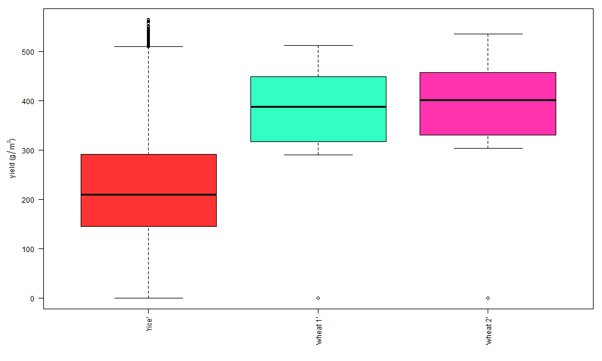

```r
knitr::include_graphics(plotName)
```

## Effect of elevation on ARID

Plotting ARID vs elevation:

```r
plotName = "plots/SIMPLE-crop-model_withSpatialDiversity/ARIDvsElevation_wheatVsRice.png"

grScale = 2
fontRescale = 0.5

png(plotName, width = grScale * 500, height = grScale * 300)

layout(matrix(c(1, 2, 3, 4, 4, 4), nrow = 3, ncol = 2),
       heights = c(10, 10, 2), widths = c(10, 3))

par(mar = c(1,5,1,1), cex.lab = 0.8 * grScale)

plot(c(minElevation, maxElevation),
     c(minARID, maxARID),
     xaxt ='n',
     xlab = "",
     ylab = "mean ARID (current year)")

for (aCrop in levels(yieldData$crop))
{
  points(yieldData$elevation[yieldData$crop == aCrop],
         yieldData$meanARID[yieldData$crop == aCrop],
         col = cropColours[match(aCrop, levels(yieldData$crop))],
         pch = 20
  )
  abline(lm(meanARID ~ elevation, data = yieldData[yieldData$crop == aCrop,]),
         col = cropColours[match(aCrop, levels(yieldData$crop))],
         lwd = 2)
}

plot(c(minElevation, maxElevation),
     c(minARID, maxARID),
     xaxt ='n',
     xlab = "",
     ylab = "mean ARID (grow seasons)")

for (aCrop in levels(yieldData$crop))
{
  points(yieldData$elevation[yieldData$crop == aCrop],
         yieldData$meanARID_grow[yieldData$crop == aCrop],
         col = cropColours[match(aCrop, levels(yieldData$crop))],
         pch = 20
  )
  abline(lm(meanARID_grow ~ elevation, data = yieldData[yieldData$crop == aCrop,]),
         col = cropColours[match(aCrop, levels(yieldData$crop))],
         lwd = 2)
}

par(mar = c(1, 1, 1, 0.1))

plot(c(minElevation, maxElevation), c(0, 1), ann = F, bty = 'n', type = 'n', xaxt = 'n', yaxt = 'n')

axis(3,
     at = seq(minElevation, maxElevation, by = 5),
     tck = 0, lwd = 0)

mtext("elevation (m)", side = 1, line = -2)

par(mar = c(0, 0, 0, 0), cex = 0.8 * grScale)

plot(c(0, 1), c(0, 1), ann = F, bty = 'n', type = 'n', xaxt = 'n', yaxt = 'n')

legend(x = 0, y = 1,
       legend = stringi::stri_c(cropTable$S_water[cropTable$crop %in% wheatAndRice], " (", levels(yieldData$crop), ")"),
       title = "S_water (Crop-cultivar)",
       fill = cropColours)

dev.off()
```

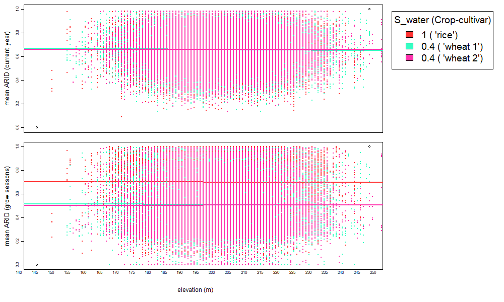

```r
knitr::include_graphics(plotName)
```

Calculate correlation and linear models fitness:

```r
linearModels.table <- data.frame(
  levels(yieldData$crop),
  numeric(nlevels(yieldData$crop)),
  numeric(nlevels(yieldData$crop)),
  numeric(nlevels(yieldData$crop)),
  numeric(nlevels(yieldData$crop)),
  numeric(nlevels(yieldData$crop)),
  numeric(nlevels(yieldData$crop))
)

names(linearModels.table) <- c("crop", "correlation_Pearson", "intercept", "intercept_p", "speed", "speed_p", "adjrsquared")

for (aCrop in levels(yieldData$crop))
{
  linearModels.table$correlation_Pearson[linearModels.table$crop == aCrop] <-
    cor(x = yieldData$elevation[yieldData$crop == aCrop], y = yieldData$meanARID_grow[yieldData$crop == aCrop], use = "pairwise.complete.obs")

  linearModel <- lm(meanARID_grow ~ elevation, data = yieldData[yieldData$crop == aCrop,])

  linearModels.table$intercept[linearModels.table$crop == aCrop] <- summary(linearModel)$coefficients[1,1]
  linearModels.table$intercept_p[linearModels.table$crop == aCrop] <- summary(linearModel)$coefficients[1,4]
  linearModels.table$speed[linearModels.table$crop == aCrop] <- summary(linearModel)$coefficients[2,1]
  linearModels.table$speed_p[linearModels.table$crop == aCrop] <- summary(linearModel)$coefficients[2,4]
  linearModels.table$adjrsquared[linearModels.table$crop == aCrop] <- summary(linearModel)$adj.r.squared
}
```

```r
knitr::kable(linearModels.table)
```

| crop | correlation_Pearson | intercept | intercept_p | speed | speed_p | adjrsquared |
| --- | --- | --- | --- | --- | --- | --- |
| ‘rice’ | -0.0049897 | 0.7164653 | 0 | -6.63e-05 | 0.3857734 | -8.20e-06 |
| ‘wheat 1’ | -0.0080609 | 0.5373838 | 0 | -1.21e-04 | 0.2146372 | 2.28e-05 |
| ‘wheat 2’ | 0.0037392 | 0.4969948 | 0 | 5.63e-05 | 0.5654026 | -2.83e-05 |

## Effect of drainage coefficient (DC) on ARID

Plotting ARID vs drainage coefficient:

```r
plotName = "plots/SIMPLE-crop-model_withSpatialDiversity/ARIDvsDC_wheatVsRice.png"

grScale = 2
fontRescale = 0.5

png(plotName, width = grScale * 500, height = grScale * 300)

layout(matrix(c(1, 2, 3, 4, 4, 4), nrow = 3, ncol = 2),
       heights = c(10, 10, 2), widths = c(10, 3))

par(mar = c(1,5,1,1), cex.lab = 0.8 * grScale)

plot(c(minDC, maxDC),
     c(minARID, maxARID),
     xaxt ='n',
     xlab = "",
     ylab = "mean ARID (current year)")

for (aCrop in levels(yieldData$crop))
{
  points(yieldData$DC[yieldData$crop == aCrop],
         yieldData$meanARID[yieldData$crop == aCrop],
         col = cropColours[match(aCrop, levels(yieldData$crop))],
         pch = 20
  )
  abline(lm(meanARID ~ DC, data = yieldData[yieldData$crop == aCrop,]),
         col = cropColours[match(aCrop, levels(yieldData$crop))],
         lwd = 2)
}

plot(c(minDC, maxDC),
     c(minARID, maxARID),
     xaxt ='n',
     xlab = "",
     ylab = "mean ARID (grow seasons)")

for (aCrop in levels(yieldData$crop))
{
  points(yieldData$DC[yieldData$crop == aCrop],
         yieldData$meanARID_grow[yieldData$crop == aCrop],
         col = cropColours[match(aCrop, levels(yieldData$crop))],
         pch = 20
  )
  abline(lm(meanARID_grow ~ DC, data = yieldData[yieldData$crop == aCrop,]),
         col = cropColours[match(aCrop, levels(yieldData$crop))],
         lwd = 2)
}

par(mar = c(1, 1, 1, 0.1))

plot(c(minDC, maxDC), c(0, 1), ann = F, bty = 'n', type = 'n', xaxt = 'n', yaxt = 'n')

axis(3,
     at = seq(minDC, maxDC, by = 0.05),
     tck = 0, lwd = 0)

mtext(expression("drainage coefficient " (m^3*m^-3) ), side = 1, line = -2)

par(mar = c(0, 0, 0, 0), cex = 0.8 * grScale)

plot(c(0, 1), c(0, 1), ann = F, bty = 'n', type = 'n', xaxt = 'n', yaxt = 'n')

legend(x = 0, y = 1,
       legend = stringi::stri_c(cropTable$S_water[cropTable$crop %in% wheatAndRice], " (", levels(yieldData$crop), ")"),
       title = "S_water (Crop-cultivar)",
       fill = cropColours)

dev.off()
```

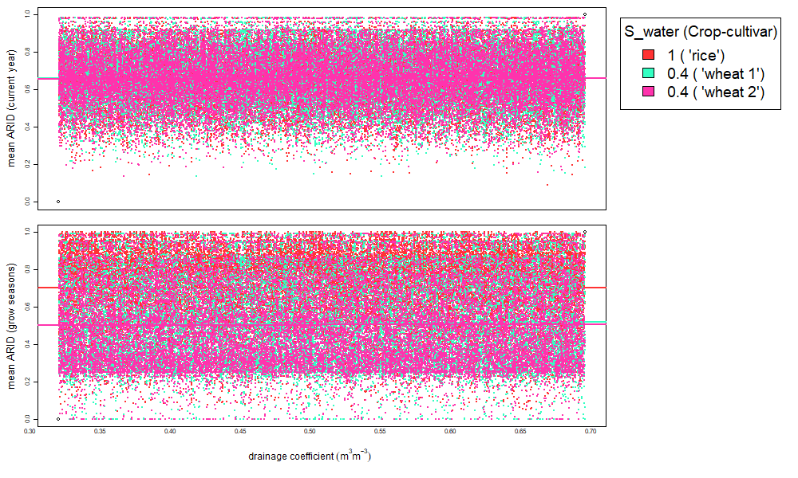

```r
knitr::include_graphics(plotName)
```

Calculate correlation and linear models fitness:

```r
linearModels.table <- data.frame(
  levels(yieldData$crop),
  numeric(nlevels(yieldData$crop)),
  numeric(nlevels(yieldData$crop)),
  numeric(nlevels(yieldData$crop)),
  numeric(nlevels(yieldData$crop)),
  numeric(nlevels(yieldData$crop)),
  numeric(nlevels(yieldData$crop))
)

names(linearModels.table) <- c("crop", "correlation_Pearson", "intercept", "intercept_p", "speed", "speed_p", "adjrsquared")

for (aCrop in levels(yieldData$crop))
{
  linearModels.table$correlation_Pearson[linearModels.table$crop == aCrop] <-
    cor(x = yieldData$DC[yieldData$crop == aCrop], y = yieldData$meanARID_grow[yieldData$crop == aCrop], use = "pairwise.complete.obs")

  linearModel <- lm(meanARID_grow ~ DC, data = yieldData[yieldData$crop == aCrop,])

  linearModels.table$intercept[linearModels.table$crop == aCrop] <- summary(linearModel)$coefficients[1,1]
  linearModels.table$intercept_p[linearModels.table$crop == aCrop] <- summary(linearModel)$coefficients[1,4]
  linearModels.table$speed[linearModels.table$crop == aCrop] <- summary(linearModel)$coefficients[2,1]
  linearModels.table$speed_p[linearModels.table$crop == aCrop] <- summary(linearModel)$coefficients[2,4]
  linearModels.table$adjrsquared[linearModels.table$crop == aCrop] <- summary(linearModel)$adj.r.squared
}
```

```r
knitr::kable(linearModels.table)
```

| crop | correlation_Pearson | intercept | intercept_p | speed | speed_p | adjrsquared |
| --- | --- | --- | --- | --- | --- | --- |
| ‘rice’ | 0.0042297 | 0.6997952 | 0 | 0.0068344 | 0.4622206 | -0.0000152 |
| ‘wheat 1’ | 0.0227284 | 0.4918145 | 0 | 0.0426985 | 0.0004665 | 0.0004744 |
| ‘wheat 2’ | 0.0111673 | 0.4980329 | 0 | 0.0203837 | 0.0860111 | 0.0000824 |

## Effect of water holding capacity (WHC) on ARID

Plotting ARID vs water holding capacity:

```r
plotName = "plots/SIMPLE-crop-model_withSpatialDiversity/ARIDvsWHC_wheatVsRice.png"

grScale = 2
fontRescale = 0.5

png(plotName, width = grScale * 500, height = grScale * 300)

layout(matrix(c(1, 2, 3, 4, 4, 4), nrow = 3, ncol = 2),
       heights = c(10, 10, 2), widths = c(10, 3))

par(mar = c(1,5,1,1), cex.lab = 0.8 * grScale)

plot(c(minWHC, maxWHC),
     c(minARID, maxARID),
     xaxt ='n',
     xlab = "",
     ylab = "mean ARID (current year)")

for (aCrop in levels(yieldData$crop))
{
  points(yieldData$WHC[yieldData$crop == aCrop],
         yieldData$meanARID[yieldData$crop == aCrop],
         col = cropColours[match(aCrop, levels(yieldData$crop))],
         pch = 20
  )
  abline(lm(meanARID ~ WHC, data = yieldData[yieldData$crop == aCrop,]),
         col = cropColours[match(aCrop, levels(yieldData$crop))],
         lwd = 2)
}

plot(c(minWHC, maxWHC),
     c(minARID, maxARID),
     xaxt ='n',
     xlab = "",
     ylab = "mean ARID (grow seasons)")

for (aCrop in levels(yieldData$crop))
{
  points(yieldData$WHC[yieldData$crop == aCrop],
         yieldData$meanARID_grow[yieldData$crop == aCrop],
         col = cropColours[match(aCrop, levels(yieldData$crop))],
         pch = 20
  )
  abline(lm(meanARID_grow ~ WHC, data = yieldData[yieldData$crop == aCrop,]),
         col = cropColours[match(aCrop, levels(yieldData$crop))],
         lwd = 2)
}

par(mar = c(1, 1, 1, 0.1))

plot(c(minWHC, maxWHC), c(0, 1), ann = F, bty = 'n', type = 'n', xaxt = 'n', yaxt = 'n')

axis(3,
     at = seq(minWHC, maxWHC, by = 0.05),
     tck = 0, lwd = 0)

mtext(expression("water holding capacity " (m^3*m^-3) ), side = 1, line = -2)

par(mar = c(0, 0, 0, 0), cex = 0.8 * grScale)

plot(c(0, 1), c(0, 1), ann = F, bty = 'n', type = 'n', xaxt = 'n', yaxt = 'n')

legend(x = 0, y = 1,
       legend = stringi::stri_c(cropTable$S_water[cropTable$crop %in% wheatAndRice], " (", levels(yieldData$crop), ")"),
       title = "S_water (Crop-cultivar)",
       fill = cropColours)

dev.off()
```

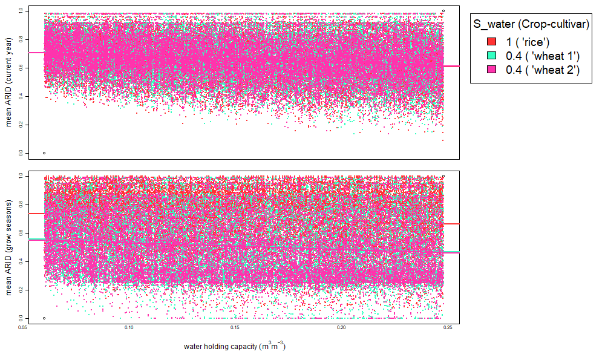

```r
knitr::include_graphics(plotName)
```

Calculate correlation and linear models fitness:

```r
linearModels.table <- data.frame(
  levels(yieldData$crop),
  numeric(nlevels(yieldData$crop)),
  numeric(nlevels(yieldData$crop)),
  numeric(nlevels(yieldData$crop)),
  numeric(nlevels(yieldData$crop)),
  numeric(nlevels(yieldData$crop)),
  numeric(nlevels(yieldData$crop))
)

names(linearModels.table) <- c("crop", "correlation_Pearson", "intercept", "intercept_p", "speed", "speed_p", "adjrsquared")

for (aCrop in levels(yieldData$crop))
{
  linearModels.table$correlation_Pearson[linearModels.table$crop == aCrop] <-
    cor(x = yieldData$WHC[yieldData$crop == aCrop], y = yieldData$meanARID_grow[yieldData$crop == aCrop], use = "pairwise.complete.obs")

  linearModel <- lm(meanARID_grow ~ WHC, data = yieldData[yieldData$crop == aCrop,])

  linearModels.table$intercept[linearModels.table$crop == aCrop] <- summary(linearModel)$coefficients[1,1]
  linearModels.table$intercept_p[linearModels.table$crop == aCrop] <- summary(linearModel)$coefficients[1,4]
  linearModels.table$speed[linearModels.table$crop == aCrop] <- summary(linearModel)$coefficients[2,1]
  linearModels.table$speed_p[linearModels.table$crop == aCrop] <- summary(linearModel)$coefficients[2,4]
  linearModels.table$adjrsquared[linearModels.table$crop == aCrop] <- summary(linearModel)$adj.r.squared
}
```

```r
knitr::kable(linearModels.table)
```

| crop | correlation_Pearson | intercept | intercept_p | speed | speed_p | adjrsquared |
| --- | --- | --- | --- | --- | --- | --- |
| ‘rice’ | -0.1129910 | 0.7575460 | 0 | -0.3637312 | 0 | 0.0127343 |
| ‘wheat 1’ | -0.1163702 | 0.5787369 | 0 | -0.4342302 | 0 | 0.0135004 |
| ‘wheat 2’ | -0.1153035 | 0.5710012 | 0 | -0.4228244 | 0 | 0.0132531 |

## Effect of albedo on ARID

Plotting ARID vs albedo:

```r
plotName = "plots/SIMPLE-crop-model_withSpatialDiversity/ARIDvsAlbedo_wheatVsRice.png"

grScale = 2
fontRescale = 0.5

png(plotName, width = grScale * 500, height = grScale * 300)

layout(matrix(c(1, 2, 3, 4, 4, 4), nrow = 3, ncol = 2),
       heights = c(10, 10, 2), widths = c(10, 3))

par(mar = c(1,5,1,1), cex.lab = 0.8 * grScale)

plot(c(minAlbedo, maxAlbedo),
     c(minARID, maxARID),
     xaxt ='n',
     xlab = "",
     ylab = "mean ARID (current year)")

for (aCrop in levels(yieldData$crop))
{
  points(yieldData$albedo[yieldData$crop == aCrop],
         yieldData$meanARID[yieldData$crop == aCrop],
         col = cropColours[match(aCrop, levels(yieldData$crop))],
         pch = 20
  )
  abline(lm(meanARID ~ albedo, data = yieldData[yieldData$crop == aCrop,]),
         col = cropColours[match(aCrop, levels(yieldData$crop))],
         lwd = 2)
}

plot(c(minAlbedo, maxAlbedo),
     c(minARID, maxARID),
     xaxt ='n',
     xlab = "",
     ylab = "mean ARID (grow seasons)")

for (aCrop in levels(yieldData$crop))
{
  points(yieldData$albedo[yieldData$crop == aCrop],
         yieldData$meanARID_grow[yieldData$crop == aCrop],
         col = cropColours[match(aCrop, levels(yieldData$crop))],
         pch = 20
  )
  abline(lm(meanARID_grow ~ albedo, data = yieldData[yieldData$crop == aCrop,]),
         col = cropColours[match(aCrop, levels(yieldData$crop))],
         lwd = 2)
}

par(mar = c(1, 1, 1, 0.1))

plot(c(minAlbedo, maxAlbedo), c(0, 1), ann = F, bty = 'n', type = 'n', xaxt = 'n', yaxt = 'n')

axis(3,
     at = seq(minAlbedo, maxAlbedo, by = 0.05),
     tck = 0, lwd = 0)

mtext("albedo", side = 1, line = -2)

par(mar = c(0, 0, 0, 0), cex = 0.8 * grScale)

plot(c(0, 1), c(0, 1), ann = F, bty = 'n', type = 'n', xaxt = 'n', yaxt = 'n')

legend(x = 0, y = 1,
       legend = stringi::stri_c(cropTable$S_water[cropTable$crop %in% wheatAndRice], " (", levels(yieldData$crop), ")"),
       title = "S_water (Crop-cultivar)",
       fill = cropColours)

dev.off()
```

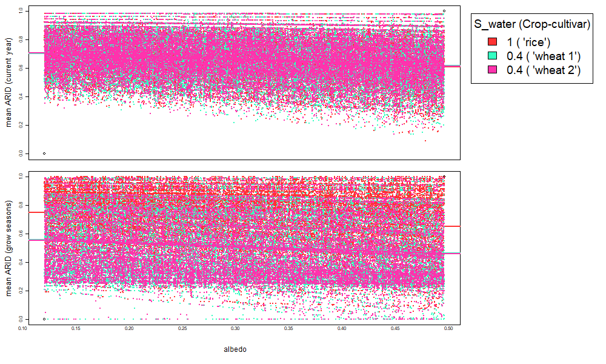

```r
knitr::include_graphics(plotName)
```

Calculate correlation and linear models fitness:

```r
linearModels.table <- data.frame(
  levels(yieldData$crop),
  numeric(nlevels(yieldData$crop)),
  numeric(nlevels(yieldData$crop)),
  numeric(nlevels(yieldData$crop)),
  numeric(nlevels(yieldData$crop)),
  numeric(nlevels(yieldData$crop)),
  numeric(nlevels(yieldData$crop))
)

names(linearModels.table) <- c("crop", "correlation_Pearson", "intercept", "intercept_p", "speed", "speed_p", "adjrsquared")

for (aCrop in levels(yieldData$crop))
{
  linearModels.table$correlation_Pearson[linearModels.table$crop == aCrop] <-
    cor(x = yieldData$albedo[yieldData$crop == aCrop], y = yieldData$meanARID_grow[yieldData$crop == aCrop], use = "pairwise.complete.obs")

  linearModel <- lm(meanARID_grow ~ albedo, data = yieldData[yieldData$crop == aCrop,])

  linearModels.table$intercept[linearModels.table$crop == aCrop] <- summary(linearModel)$coefficients[1,1]
  linearModels.table$intercept_p[linearModels.table$crop == aCrop] <- summary(linearModel)$coefficients[1,4]
  linearModels.table$speed[linearModels.table$crop == aCrop] <- summary(linearModel)$coefficients[2,1]
  linearModels.table$speed_p[linearModels.table$crop == aCrop] <- summary(linearModel)$coefficients[2,4]
  linearModels.table$adjrsquared[linearModels.table$crop == aCrop] <- summary(linearModel)$adj.r.squared
}
```

```r
knitr::kable(linearModels.table)
```

| crop | correlation_Pearson | intercept | intercept_p | speed | speed_p | adjrsquared |
| --- | --- | --- | --- | --- | --- | --- |
| ‘rice’ | -0.1513211 | 0.7760113 | 0 | -0.2423391 | 0 | 0.0228657 |
| ‘wheat 1’ | -0.1220623 | 0.5820608 | 0 | -0.2289755 | 0 | 0.0148576 |
| ‘wheat 2’ | -0.1250768 | 0.5777173 | 0 | -0.2304428 | 0 | 0.0156026 |

## Effect of albedo on yield

Plotting yield vs albedo:

```r
plotName = "plots/SIMPLE-crop-model_withSpatialDiversity/yieldvsAlbedo_wheatVsRice.png"

grScale = 2
fontRescale = 0.5

png(plotName, width = grScale * 500, height = grScale * 300)

layout(matrix(c(1, 2), nrow = 1, ncol = 2), widths = c(10, 3))

par(mar = c(5,5,1,1), cex.lab = 0.8 * grScale)

plot(c(minAlbedo, maxAlbedo),
     c(minYield, maxYield),
     xlab = "albedo",
     ylab = "yield")

for (aCrop in levels(yieldData$crop))
{
  points(yieldData$albedo[yieldData$crop == aCrop],
         yieldData$yield[yieldData$crop == aCrop],
         col = cropColours[match(aCrop, levels(yieldData$crop))],
         pch = 20
  )
  abline(lm(yield ~ albedo, data = yieldData[yieldData$crop == aCrop,]),
         col = cropColours[match(aCrop, levels(yieldData$crop))],
         lwd = 2)
}

par(mar = c(0, 0, 0, 0), cex = 0.8 * grScale)

plot(c(0, 1), c(0, 1), ann = F, bty = 'n', type = 'n', xaxt = 'n', yaxt = 'n')

legend(x = 0, y = 1,
       legend = stringi::stri_c(cropTable$S_water[cropTable$crop %in% wheatAndRice], " (", levels(yieldData$crop), ")"),
       title = "S_water (Crop-cultivar)",
       fill = cropColours)

dev.off()
```

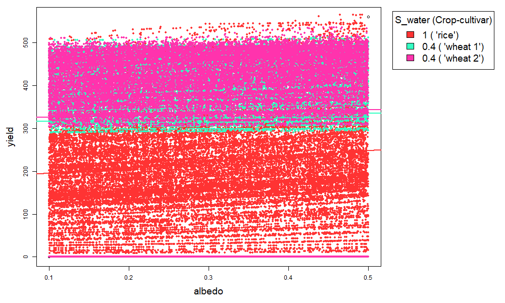

```r
knitr::include_graphics(plotName)
```

Calculate correlation and linear models fitness:

```r
linearModels.table <- data.frame(
  levels(yieldData$crop),
  numeric(nlevels(yieldData$crop)),
  numeric(nlevels(yieldData$crop)),
  numeric(nlevels(yieldData$crop)),
  numeric(nlevels(yieldData$crop)),
  numeric(nlevels(yieldData$crop)),
  numeric(nlevels(yieldData$crop))
)

names(linearModels.table) <- c("crop", "correlation_Pearson", "intercept", "intercept_p", "speed", "speed_p", "adjrsquared")

for (aCrop in levels(yieldData$crop))
{
  linearModels.table$correlation_Pearson[linearModels.table$crop == aCrop] <-
    cor(x = yieldData$albedo[yieldData$crop == aCrop], y = yieldData$yield[yieldData$crop == aCrop], use = "pairwise.complete.obs")

  linearModel <- lm(yield ~ albedo, data = yieldData[yieldData$crop == aCrop,])

  linearModels.table$intercept[linearModels.table$crop == aCrop] <- summary(linearModel)$coefficients[1,1]
  linearModels.table$intercept_p[linearModels.table$crop == aCrop] <- summary(linearModel)$coefficients[1,4]
  linearModels.table$speed[linearModels.table$crop == aCrop] <- summary(linearModel)$coefficients[2,1]
  linearModels.table$speed_p[linearModels.table$crop == aCrop] <- summary(linearModel)$coefficients[2,4]
  linearModels.table$adjrsquared[linearModels.table$crop == aCrop] <- summary(linearModel)$adj.r.squared
}
```

```r
knitr::kable(linearModels.table)
```

| crop | correlation_Pearson | intercept | intercept_p | speed | speed_p | adjrsquared |
| --- | --- | --- | --- | --- | --- | --- |
| ‘rice’ | 0.1356812 | 182.9596 | 0 | 130.89453 | 0e+00 | 0.0183769 |
| ‘wheat 1’ | 0.0300694 | 312.8942 | 0 | 44.60619 | 2e-07 | 0.0008704 |
| ‘wheat 2’ | 0.0292444 | 321.8016 | 0 | 44.00976 | 5e-07 | 0.0008214 |